# Installing the Package

```python
pip3 install equities
```

# Initializing an Equity Universe

```python
from equities import Universe
u = Universe()
```

[output not shown]

# Basic Methods

To get the number of companies in the universe call:

```python
len(u)
```

```
4128
```

"CIK" numbers are the sec's official unique identifier for public companies.It stands for "Central Index Key" A full list of the cik numbers in the universe is found in:

```python
u.ciks[:10] # returns a list of ciks of stocks in the universe
```

```
['1122304',
 '8192',
 '1015820',
 '1581068',
 '917520',
 '704532',
 '1024020',
 '1548309',
 '1441816',
 '40987']
```

Similarly, if we want the names of companies in the universe we can call:

```python
u.names[:10] # returns a list of names in the universe
```

```
['AETNA INC /PA/',
 'ATLANTIC CITY ELECTRIC CO',
 'QIAGEN NV',
 'BRIXMOR PROPERTY GROUP INC.',
 'INTEGRA LIFESCIENCES HOLDINGS CORP',
 'NANOMETRICS INC',
 'TC X CALIBUR INC',
 'SEARS HOMETOWN & OUTLET STORES, INC.',
 'MONGODB, INC.',
 'GENUINE PARTS CO']
```

Finally, to get tickers we call:

```python
u.tickers[:10] # returns a list of tickers in the universe
```

```
['', 'tcmd', 'inbp', 'rrbi', 'cvly', 'mdb', 'bngo', 'nbix', 'morn', 'ke']
```

# Conversions

To get a dictionary mapping "cik" numbers to the names of companies execute:

```python
u.cik_to_name()
```

```
{'1122304': 'AETNA INC /PA/',
 '8192': 'ATLANTIC CITY ELECTRIC CO',
 '1015820': 'QIAGEN NV',
 '1581068': 'BRIXMOR PROPERTY GROUP INC.',
 '917520': 'INTEGRA LIFESCIENCES HOLDINGS CORP',
 '704532': 'NANOMETRICS INC',
 '1024020': 'TC X CALIBUR INC',
 '1548309': 'SEARS HOMETOWN & OUTLET STORES, INC.',
 '1441816': 'MONGODB, INC.',
 '40987': 'GENUINE PARTS CO',
 '73756': 'OCEANEERING INTERNATIONAL INC',
 '1556508': 'GREEN LIVING CONCEPTS INC.',
 '1171486': 'NATURAL RESOURCE PARTNERS LP',
 '1032220': 'MAXIMUS, INC.',
 '90144': 'SIERRA PACIFIC POWER CO',
 '802851': 'LOGIC DEVICES INC',
 '1613859': 'PRA HEALTH SCIENCES, INC.',
 '1564708': 'NEWS CORP',
 '1163302': 'UNITED STATES STEEL CORP',
 '106535': 'WEYERHAEUSER CO',
 '1212458': 'PROOFPOINT INC',
 '1171500': 'PLATINUM UNDERWRITERS HOLDINGS LTD',
 '49196': 'HUNTINGTON BANCSHARES INC/MD',
 '1425450': 'ORTHOPEDIATRICS CORP',
 '90168': 'SIFCO INDUSTRIES INC',
 '1507385': 'VEREIT, INC.',
 '1433660': 'JOHN BEAN TECHNOLOGIES CORP',
 '1712184': 'LIBERTY LATIN AMERICA LTD.',
 '1712189': 'TARGET HOSPITALITY CORP.',
 '1597503': 'NORTHSTAR ASSET MANAGEMENT GROUP INC.',
 '1171520': 'PLYMOUTH INDUSTRIAL REIT INC.',
 '1499200': 'SABINE PASS LIQUEFACTION, LLC',
 '1163332': 'VERTICAL HEALTH SOLUTIONS INC',
 '745544': 'SUN LIFE ASSURANCE CO OF CANADA (U.S.)',
 '90185': 'SIGMA ALDRICH CORP',
 '1065034': 'MAGMA DESIGN AUTOMATION INC',
 '1359948': 'ALLIANCE FIBER OPTIC PRODUCTS INC',
 '1286225': 'REALPAGE, INC.',
 '1376339': 'MIMEDX GROUP, INC.',
 '1122388': 'ELLIE MAE INC',
```

[output cut: 946 more lines]

```
 '1157075': 'NUVILEX, INC.',
 '92122': 'SOUTHERN CO',
 '1009626': 'BROCADE COMMUNICATIONS SYSTEMS INC',
 '18396': 'CDI CORP',
 '34782': '1ST SOURCE CORP',
 '878560': 'CALATLANTIC GROUP, INC.',
 '1116132': 'TAPESTRY, INC.',
 '1583077': 'HOSPITALITY INVESTORS TRUST, INC.',
 '1509351': 'CHARLIE GPS INC',
 '1533932': 'WORLDPAY, INC.',
 '1091566': 'CYIOS CORP',
 '1329136': 'MICROELECTRONICS TECHNOLOGY CO',
 '1411059': 'KBS REAL ESTATE INVESTMENT TRUST II, INC.',
 '1206264': 'TEMPUR SEALY INTERNATIONAL, INC.',
 ...}
```

We can get get a map of cik numbers to tickers through :

```python
u.cik_to_ticker()
```

```python
# The inverses of both of these dictionaries are also accessible through:

u.name_to_cik()

u.ticker_to_cik()
```

# Search

You can search for companies by names, ticker or ciks by using the search function. Note that in all universe queries handle for case and whitespace.

```python
u.search("mongodb")
```

```
> 🛰️	Search query: "mongodb" found 1 matches.
```

```
{'MONGODB, INC.': '1441816'}
```

```python
u.search("nflx")
```

```
> 🛰️	Search query: "nflx" found 1 matches.
```

```
{'NETFLIX INC': '1065280'}
```

```python
u.search('oil')
```

```
> 🛰️	Search query: "oil" found 23 matches.
```

```
{'APCO OIL & GAS INTERNATIONAL INC': '311471',
 'CARRIZO OIL & GAS INC': '1040593',
 'EXTRACTION OIL & GAS, INC.': '1655020',
 'OIL-DRI CORP OF AMERICA': '74046',
 'OILTANKING PARTNERS, L.P.': '1516007',
 'NEXTIER OILFIELD SOLUTIONS INC.': '1688476',
 'SOLARIS OILFIELD INFRASTRUCTURE, INC.': '1697500',
 'BRENHAM OIL & GAS CORP.': '1501720',
 'MAGNOLIA OIL & GAS CORP': '1698990',
 'MARATHON OIL CORP': '101778',
 'PANHANDLE OIL & GAS INC': '315131',
 'FRONTIER OIL CORP /NEW/': '110430',
 'KODIAK OIL & GAS CORP': '1322866',
 'EPL OIL & GAS, INC.': '750199',
 'FOREST OIL CORP': '38079',
 'ICON OIL & GAS FUND-A L.P.': '947986',
 'LIBERTY OILFIELD SERVICES INC.': '1694028',
 'NORTHERN OIL & GAS, INC.': '1104485',
 'SPINDLETOP OIL & GAS CO': '867038',
 'CONTANGO OIL & GAS CO': '1071993',
 'OILSANDS QUEST INC': '1096791',
 'OIL STATES INTERNATIONAL, INC': '1121484',
 'UNITED STATES OIL FUND, LP': '1171200'}
```

# Company Queries

company data can be obtained by passing a "cik" or "ticker" into the "company()" function on the universe.

```python
data = u.company('nflx')

# we can also pass in a query like this: u.company("Netflix",search=True).
# It returns the first result of the search query.
```

```
> 📦	Fetching company: 1065280 ...
```

The above requests returns a dictionary. Here are it's keys:

```python
for i,elem in enumerate(data.keys(),start=1):
    print('\t%s) %s'%(str(i),elem))
```

```
	1) name
	2) sic
	3) business_address
	4) mailing_address
	5) phone
	6) country_incorporated
	7) state_incorporated
	8) ein
	9) former_name
	10) income
	11) balance
	12) cash
	13) equity
	14) prices
	15) actions
	16) dividends
	17) splits
	18) major_holders
	19) institutional_holders
	20) events
	21) recommendations
	22) esg
	23) interest
```

let's take a look at each one of these.

```python
data['name']
```

```
'NETFLIX INC'
```

```python
data['sic']
```

```
'7841.0'
```

```python
data['business_address']
```

```
{'country': 'US',
 'city': 'LOS GATOS',
 'zip': '95032',
 'adr1': '100 WINCHESTER CIRCLE',
 'adr2': '.'}
```

```python
data['mailing_address']
```

```
{'country': 'US',
 'city': 'LOS GATOS',
 'zip': '95032-7606',
 'adr1': '100 WINCHESTER CIRCLE',
 'adr2': 'nan',
 'state': 'CA'}
```

```python
data['phone']
```

```
'408-540-3700'
```

```python
data['country_incorporated']
```

```
'US'
```

```python
data['state_incorporated']
```

```
'DE'
```

```python
data['ein']
```

```
'770467272.0'
```

```python
data['former_name']
```

```
'NETFLIX COM INC'
```

```python
data['income']
```

|  | 2009q2 | 2009q3 | 2009q4 | 2010q1 | 2010q2 | 2010q3 | 2010q4 | 2011q2 | 2011q3 | 2011q4 | ... | 2018q1 | 2018q2 | 2018q3 | 2018q4 | 2019q1 | 2019q2 | 2019q3 | 2019q4 | 2020q2 | 2020q3 |
| --- | --- | --- | --- | --- | --- | --- | --- | --- | --- | --- | --- | --- | --- | --- | --- | --- | --- | --- | --- | --- | --- |
| Revenues | None | None | None | None | None | None | None | None | None | None | ... | 6.779511e+09 | 2.636635e+09 | 2.785464e+09 | 2.984859e+09 | 2.984859e+09 | 3.700856e+09 | 3.907270e+09 | 3.999374e+09 | 5.767691e+09 | 6.148286e+09 |
| CostOfRevenue | None | None | None | None | None | None | None | None | None | None | ... | 7.659666e+09 | 2.196075e+09 | 4.485942e+09 | 6.898288e+09 | 6.257462e+09 | 2.300579e+09 | 5.876271e+09 | 8.974190e+09 | 2.870614e+09 | 3.643707e+09 |
| MarketingExpense | None | None | None | None | None | None | None | None | None | None | ... | 8.240920e+08 | 2.712700e+08 | 5.455930e+08 | 8.580830e+08 | 3.144470e+08 | 6.165780e+08 | 5.920070e+08 | 5.103300e+08 | 5.038300e+08 | 1.219728e+09 |
| ResearchAndDevelopmentExpense | None | None | None | None | None | None | None | None | None | None | ... | NaN | 2.571080e+08 | 6.179430e+08 | 9.449690e+08 | NaN | 2.823100e+08 | 5.814050e+08 | 8.900250e+08 | 4.538170e+08 | 3.832330e+08 |
| GeneralAndAdministrativeExpense | None | None | None | None | None | None | None | None | None | None | ... | 8.635680e+08 | 2.782510e+08 | 5.894480e+08 | 9.335130e+08 | 1.124590e+08 | 2.019520e+08 | 1.515240e+08 | 1.686280e+08 | 2.520870e+08 | 2.246570e+08 |
| OperatingIncomeLoss | None | None | None | None | None | None | None | None | None | None | ... | 3.058260e+08 | 2.569420e+08 | 9.087910e+08 | 1.389459e+09 | 3.797930e+08 | 4.465780e+08 | 4.622130e+08 | 4.806680e+08 | 4.590840e+08 | 7.064190e+08 |
| InterestExpense | None | None | None | None | None | None | None | None | None | None | ... | 1.327160e+08 | 8.121900e+07 | 5.548200e+07 | 6.068800e+07 | 4.204930e+08 | 1.355290e+08 | 2.875620e+08 | 4.482220e+08 | 1.355290e+08 | 1.891510e+08 |
| NonoperatingIncomeExpense | None | None | None | None | None | None | None | None | None | None | ... | -3.122500e+07 | -6.574300e+07 | 2.285000e+06 | 9.289000e+06 | 3.082800e+07 | 7.610400e+07 | 6.802800e+07 | 7.004000e+06 | 2.169700e+07 | 2.263400e+07 |
| IncomeLossFromContinuingOperationsBeforeIncomeTaxesMinorityInterestAndIncomeLossFromEquityMethodInvestments | None | None | None | None | None | None | None | None | None | None | ... | 1.418850e+08 | 2.996160e+08 | 1.396200e+07 | 1.162370e+08 | 1.226458e+09 | 3.996590e+08 | 7.282520e+08 | 1.107062e+09 | 7.958700e+08 | 9.005750e+08 |
| IncomeTaxExpenseBenefit | None | None | None | None | None | None | None | None | None | None | ... | 7.382900e+07 | 9.492000e+06 | -5.163800e+07 | -1.335300e+07 | 1.521600e+07 | 9.492000e+06 | 4.428700e+07 | 6.329520e+08 | 8.680300e+07 | 3.154060e+08 |
| NetIncomeLoss | None | None | None | None | None | None | None | None | None | None | ... | 5.151700e+07 | 1.782220e+08 | 6.560000e+07 | 1.295900e+08 | 4.028350e+08 | 2.901240e+08 | 3.843490e+08 | 4.028350e+08 | 3.440520e+08 | 2.706500e+08 |
| EarningsPerShareBasic | None | None | None | None | None | None | None | None | None | None | ... | 1.290000e+00 | 4.100000e-01 | 5.700000e-01 | 8.700000e-01 | 6.700000e-01 | 7.900000e-01 | 8.800000e-01 | 9.200000e-01 | 7.900000e-01 | 6.200000e-01 |
| EarningsPerShareDiluted | None | None | None | None | None | None | None | None | None | None | ... | 1.200000e-01 | 6.400000e-01 | 8.500000e-01 | 8.900000e-01 | 8.900000e-01 | 7.600000e-01 | 1.360000e+00 | 2.830000e+00 | 7.600000e-01 | 1.360000e+00 |
| WeightedAverageNumberOfSharesOutstandingBasic | None | None | None | None | None | None | None | None | None | None | ... | 4.318850e+08 | 4.341740e+08 | 4.346380e+08 | 4.350330e+08 | 4.318850e+08 | 4.341740e+08 | 4.375870e+08 | 4.380900e+08 | 4.369470e+08 | 4.375870e+08 |
| WeightedAverageNumberOfDilutedSharesOutstanding | None | None | None | None | None | None | None | None | None | None | ... | 4.468140e+08 | 4.503590e+08 | 4.509580e+08 | 4.512830e+08 | 4.386520e+08 | 4.503590e+08 | 4.520630e+08 | 4.518960e+08 | 4.519220e+08 | 4.520630e+08 |
| GainsLossesOnExtinguishmentOfDebt | None | None | None | None | None | None | None | None | None | None | ... | NaN | NaN | NaN | NaN | NaN | NaN | NaN | NaN | NaN | NaN |
| OtherNonoperatingIncome | None | None | None | None | None | None | None | None | None | None | ... | NaN | NaN | NaN | NaN | NaN | NaN | NaN | NaN | NaN | NaN |
| CostOfGoodsSoldSubscription | None | None | None | None | None | None | None | None | None | None | ... | NaN | NaN | NaN | NaN | NaN | NaN | NaN | NaN | NaN | NaN |
| FulfillmentExpense | None | None | None | None | None | None | None | None | None | None | ... | NaN | NaN | NaN | NaN | NaN | NaN | NaN | NaN | NaN | NaN |
| GrossProfit | None | None | None | None | None | None | None | None | None | None | ... | NaN | NaN | NaN | NaN | NaN | NaN | NaN | NaN | NaN | NaN |
| OperatingExpenses | None | None | None | None | None | None | None | None | None | None | ... | NaN | NaN | NaN | NaN | NaN | NaN | NaN | NaN | NaN | NaN |
| TechnologyandDevelopmentExpense | None | None | None | None | None | None | None | None | None | None | ... | 8.520980e+08 | NaN | NaN | NaN | 1.866100e+08 | NaN | NaN | NaN | NaN | NaN |

22 rows × 44 columns

```python
data['balance']
```

|  | 2009q2 | 2009q3 | 2009q4 | 2010q1 | 2010q2 | 2010q3 | 2010q4 | 2011q2 | 2011q3 | 2011q4 | ... | 2018q1 | 2018q2 | 2018q3 | 2018q4 | 2019q1 | 2019q2 | 2019q3 | 2019q4 | 2020q2 | 2020q3 |
| --- | --- | --- | --- | --- | --- | --- | --- | --- | --- | --- | --- | --- | --- | --- | --- | --- | --- | --- | --- | --- | --- |
| CommonStockParOrStatedValuePerShare | None | None | None | None | None | None | None | None | None | None | ... | 1.000000e-03 | 1.000000e-03 | 1.000000e-03 | 1.000000e-03 | 1.000000e-03 | 1.000000e-03 | 1.000000e-03 | 1.000000e-03 | 1.000000e-03 | 1.000000e-03 |
| CommonStockSharesAuthorized | None | None | None | None | None | None | None | None | None | None | ... | 4.990000e+09 | 4.990000e+09 | 4.990000e+09 | 4.990000e+09 | 4.990000e+09 | 4.990000e+09 | 4.990000e+09 | 4.990000e+09 | 4.990000e+09 | 4.990000e+09 |
| CommonStockSharesIssued | None | None | None | None | None | None | None | None | None | None | ... | 4.333927e+08 | 4.333927e+08 | 4.333927e+08 | 4.333927e+08 | 4.365986e+08 | 4.365986e+08 | 4.378349e+08 | 4.382513e+08 | 4.397806e+08 | 4.410154e+08 |
| CashAndCashEquivalentsAtCarryingValue | None | None | None | None | None | None | None | None | None | None | ... | 1.113608e+09 | 2.593666e+09 | 2.822795e+09 | 2.822795e+09 | 2.822795e+09 | 3.794483e+09 | 3.794483e+09 | 3.794483e+09 | 5.151884e+09 | 7.153248e+09 |
| AvailableForSaleSecuritiesCurrent | None | None | None | None | None | None | None | None | None | None | ... | 2.662060e+08 | NaN | NaN | NaN | NaN | NaN | NaN | NaN | NaN | NaN |
| CommonStockSharesOutstanding | None | None | None | None | None | None | None | None | None | None | ... | 4.333927e+08 | 4.333927e+08 | 4.333927e+08 | 4.333927e+08 | 4.365986e+08 | 4.365986e+08 | 4.365986e+08 | 4.382513e+08 | 4.397806e+08 | 4.388066e+08 |
| ContentAssetsNetCurrent | None | None | None | None | None | None | None | None | None | None | ... | 4.310934e+09 | 4.626522e+09 | 4.803663e+09 | 4.987916e+09 | 5.151186e+09 | NaN | NaN | NaN | NaN | NaN |
| OtherAssetsCurrent | None | None | None | None | None | None | None | None | None | None | ... | 5.362450e+08 | 5.362450e+08 | 5.362450e+08 | 5.362450e+08 | 7.484660e+08 | 8.203500e+08 | 7.484660e+08 | 7.484660e+08 | 1.295897e+09 | 1.160067e+09 |
| AssetsCurrent | None | None | None | None | None | None | None | None | None | None | ... | 7.669974e+09 | 7.669974e+09 | 9.346889e+09 | 8.729981e+09 | 7.669974e+09 | 9.694135e+09 | 9.694135e+09 | 9.694135e+09 | 6.178504e+09 | 8.564139e+09 |
| ContentAssetsNetNoncurrent | None | None | None | None | None | None | None | None | None | None | ... | 1.037106e+10 | 1.037106e+10 | 1.037106e+10 | 1.037106e+10 | 1.037106e+10 | 2.088878e+10 | NaN | 2.323499e+10 | 2.526689e+10 | 2.515512e+10 |
| PropertyPlantAndEquipmentNet | None | None | None | None | None | None | None | None | None | None | ... | 2.503950e+08 | 3.419320e+08 | 3.496460e+08 | 3.711520e+08 | 4.182810e+08 | 4.343720e+08 | 4.182810e+08 | 4.819920e+08 | 5.652210e+08 | 7.519410e+08 |
| OtherAssetsNoncurrent | None | None | None | None | None | None | None | None | None | None | ... | 3.414230e+08 | 6.784860e+08 | 6.749320e+08 | 8.566530e+08 | 6.523090e+08 | 1.726568e+09 | 1.896043e+09 | 9.010300e+08 | 2.727420e+09 | 2.727420e+09 |
| Assets | None | None | None | None | None | None | None | None | None | None | ... | 1.358661e+10 | 1.901274e+10 | 2.266354e+10 | 2.336623e+10 | 2.597440e+10 | 2.721863e+10 | 3.017134e+10 | 3.094171e+10 | 3.505991e+10 | 3.717528e+10 |
| ContentLiabilitiesCurrent | None | None | None | None | None | None | None | None | None | None | ... | 4.173041e+09 | 4.466081e+09 | 4.541087e+09 | 4.613011e+09 | 4.686019e+09 | 4.686019e+09 | NaN | 4.860542e+09 | 4.413561e+09 | 4.664733e+09 |
| AccountsPayableCurrent | None | None | None | None | None | None | None | None | None | None | ... | 3.595550e+08 | 3.595550e+08 | 4.482190e+08 | 4.414270e+08 | 5.629850e+08 | 5.629850e+08 | 4.421940e+08 | 5.629850e+08 | 6.743470e+08 | 6.743470e+08 |
| AccruedLiabilitiesCurrent | None | None | None | None | None | None | None | None | None | None | ... | 3.150940e+08 | 4.294310e+08 | 3.150940e+08 | 3.150940e+08 | 4.774170e+08 | 4.774170e+08 | 4.774170e+08 | 1.037723e+09 | 8.430430e+08 | 9.865950e+08 |
| DeferredRevenueCurrent | None | None | None | None | None | None | None | None | None | None | ... | 4.434720e+08 | 6.738920e+08 | 6.977400e+08 | 7.167230e+08 | NaN | NaN | NaN | NaN | NaN | NaN |
| LiabilitiesCurrent | None | None | None | None | None | None | None | None | None | None | ... | 4.586657e+09 | 6.005587e+09 | 6.079641e+09 | 6.298240e+09 | 5.466312e+09 | 6.487320e+09 | 6.487320e+09 | 7.257900e+09 | 6.855696e+09 | 6.855696e+09 |
| ContentLiabilitiesNoncurrent | None | None | None | None | None | None | None | None | None | None | ... | 2.894654e+09 | 3.329796e+09 | 3.329796e+09 | 3.329796e+09 | 3.329796e+09 | 3.759026e+09 | NaN | 3.759026e+09 | 3.206051e+09 | 3.208164e+09 |
| LongTermDebtNoncurrent | None | None | None | None | None | None | None | None | None | None | ... | 3.364311e+09 | 6.542373e+09 | 8.342067e+09 | 8.336586e+09 | 6.499432e+09 | 1.036006e+10 | 1.036006e+10 | 1.036006e+10 | 1.475926e+10 | 1.475926e+10 |
| OtherLiabilitiesNoncurrent | None | None | None | None | None | None | None | None | None | None | ... | 1.352460e+08 | 1.396310e+08 | 1.410710e+08 | 1.279270e+08 | 1.352460e+08 | 1.292310e+08 | 1.292310e+08 | 1.292310e+08 | 1.444276e+09 | 1.710948e+09 |
| Liabilities | None | None | None | None | None | None | None | None | None | None | ... | 1.090681e+10 | 1.613207e+10 | 1.816694e+10 | 1.835658e+10 | 1.543079e+10 | 2.151557e+10 | 2.073564e+10 | 2.408021e+10 | 2.665062e+10 | 2.639356e+10 |
| CommitmentsAndContingencies | None | None | None | None | None | None | None | None | None | None | ... | NaN | NaN | NaN | NaN | NaN | NaN | NaN | NaN | NaN | NaN |
| CommonStockValue | None | None | None | None | None | None | None | None | None | None | ... | 1.599762e+09 | 1.871396e+09 | 1.871396e+09 | 1.871396e+09 | 1.871396e+09 | 2.315988e+09 | 2.315988e+09 | 2.315988e+09 | 2.793929e+09 | 2.793929e+09 |
| AccumulatedOtherComprehensiveIncomeLossNetOfTax | None | None | None | None | None | None | None | None | None | None | ... | -4.856500e+07 | -2.055700e+07 | -1.242700e+07 | -1.450800e+07 | -1.958200e+07 | -1.958200e+07 | -1.958200e+07 | -1.958200e+07 | -2.352100e+07 | -3.407200e+07 |
| RetainedEarningsAccumulatedDeficit | None | None | None | None | None | None | None | None | None | None | ... | 1.731117e+09 | 2.021241e+09 | 2.405590e+09 | 2.808425e+09 | 1.731117e+09 | 3.288885e+09 | 2.942359e+09 | 4.224779e+09 | 5.520816e+09 | 4.811749e+09 |
| StockholdersEquity | None | None | None | None | None | None | None | None | None | None | ... | 3.581956e+09 | 3.581956e+09 | 3.581956e+09 | 3.581956e+09 | 2.223426e+09 | 5.238765e+09 | 3.581956e+09 | 3.581956e+09 | 5.703058e+09 | 7.582157e+09 |
| LiabilitiesAndStockholdersEquity | None | None | None | None | None | None | None | None | None | None | ... | 1.901274e+10 | 2.015280e+10 | 2.266354e+10 | 2.336623e+10 | 1.901274e+10 | 2.597440e+10 | 2.597440e+10 | 2.597440e+10 | 3.505991e+10 | 3.717528e+10 |
| PreferredStockParOrStatedValuePerShare | None | None | None | None | None | None | None | None | None | None | ... | 1.000000e-03 | NaN | NaN | NaN | 1.000000e-03 | NaN | NaN | NaN | NaN | NaN |
| PreferredStockSharesAuthorized | None | None | None | None | None | None | None | None | None | None | ... | 1.000000e+07 | NaN | NaN | NaN | 1.000000e+07 | NaN | NaN | NaN | NaN | NaN |
| PreferredStockSharesIssued | None | None | None | None | None | None | None | None | None | None | ... | 0.000000e+00 | NaN | NaN | NaN | 0.000000e+00 | NaN | NaN | NaN | NaN | NaN |
| PreferredStockSharesOutstanding | None | None | None | None | None | None | None | None | None | None | ... | 0.000000e+00 | NaN | NaN | NaN | 0.000000e+00 | NaN | NaN | NaN | NaN | NaN |
| PreferredStockValue | None | None | None | None | None | None | None | None | None | None | ... | 0.000000e+00 | NaN | NaN | NaN | 0.000000e+00 | NaN | NaN | NaN | NaN | NaN |
| ContentLibraryNetCurrent | None | None | None | None | None | None | None | None | None | None | ... | NaN | NaN | NaN | NaN | NaN | NaN | NaN | NaN | NaN | NaN |
| PrepaidContentCurrent | None | None | None | None | None | None | None | None | None | None | ... | NaN | NaN | NaN | NaN | NaN | NaN | NaN | NaN | NaN | NaN |
| ContentLibraryNetNoncurrent | None | None | None | None | None | None | None | None | None | None | ... | NaN | NaN | NaN | NaN | NaN | NaN | NaN | NaN | NaN | NaN |
| DueToRelatedPartiesNoncurrent | None | None | None | None | None | None | None | None | None | None | ... | NaN | NaN | NaN | NaN | NaN | NaN | NaN | NaN | NaN | NaN |
| AdditionalPaidInCapitalCommonStock | None | None | None | None | None | None | None | None | None | None | ... | NaN | NaN | NaN | NaN | NaN | NaN | NaN | NaN | NaN | NaN |
| ContractWithCustomerLiabilityCurrent | None | None | None | None | None | None | None | None | None | None | ... | NaN | NaN | NaN | NaN | 6.186220e+08 | 8.086920e+08 | 7.608990e+08 | 9.155060e+08 | 9.247450e+08 | 1.029261e+09 |
| ShortTermBorrowings | None | None | None | None | None | None | None | None | None | None | ... | NaN | NaN | NaN | NaN | NaN | NaN | NaN | NaN | 0.000000e+00 | 4.991610e+08 |
| OtherPrepaidExpenseCurrent | None | None | None | None | None | None | None | None | None | None | ... | NaN | NaN | NaN | NaN | NaN | NaN | NaN | NaN | NaN | NaN |
| ContentAccountsPayableCurrent | None | None | None | None | None | None | None | None | None | None | ... | NaN | NaN | NaN | NaN | NaN | NaN | NaN | NaN | NaN | NaN |
| ContentAccountsPayableNoncurrent | None | None | None | None | None | None | None | None | None | None | ... | NaN | NaN | NaN | NaN | NaN | NaN | NaN | NaN | NaN | NaN |
| SeniorLongTermNotes | None | None | None | None | None | None | None | None | None | None | ... | NaN | NaN | NaN | NaN | NaN | NaN | NaN | NaN | NaN | NaN |
| RelatedPartyTransactionDueFromToRelatedParty | None | None | None | None | None | None | None | None | None | None | ... | NaN | NaN | NaN | NaN | NaN | NaN | NaN | NaN | NaN | NaN |
| LicensingAssetCurrent | None | None | None | None | None | None | None | None | None | None | ... | NaN | NaN | NaN | NaN | NaN | 5.151186e+09 | NaN | 5.151186e+09 | NaN | NaN |

46 rows × 44 columns

```python
data['cash']
```

|  | 2009q2 | 2009q3 | 2009q4 | 2010q1 | 2010q2 | 2010q3 | 2010q4 | 2011q2 | 2011q3 | 2011q4 | ... | 2018q1 | 2018q2 | 2018q3 | 2018q4 | 2019q1 | 2019q2 | 2019q3 | 2019q4 | 2020q2 | 2020q3 |
| --- | --- | --- | --- | --- | --- | --- | --- | --- | --- | --- | --- | --- | --- | --- | --- | --- | --- | --- | --- | --- | --- |
| NetIncomeLoss | None | None | None | None | None | None | None | None | None | None | ... | 6.674800e+07 | 2.901240e+08 | 6.744730e+08 | 1.077308e+09 | 4.028350e+08 | 2.901240e+08 | 384349000.0 | 4.028350e+08 | 7.090670e+08 | 2.706500e+08 |
| AdditionstoStreamingContentAssets | None | None | None | None | None | None | None | None | None | None | ... | 5.771652e+09 | 2.348666e+09 | 6.020468e+09 | 9.259185e+09 | 1.304344e+10 | 2.997746e+09 | NaN | 9.971141e+09 | 3.294275e+09 | 2.510782e+09 |
| ChangeInStreamingContentLiabilities | None | None | None | None | None | None | None | None | None | None | ... | 1.162413e+09 | 3.662570e+08 | 6.673590e+08 | 7.332270e+08 | 9.000060e+08 | -1.469800e+07 | NaN | -9.554800e+07 | 2.589450e+08 | -1.084320e+08 |
| CostofServicesAmortizationofStreamingContentAssets | None | None | None | None | None | None | None | None | None | None | ... | 6.197817e+09 | 1.305683e+09 | 2.856477e+09 | 4.483954e+09 | 6.197817e+09 | 2.124686e+09 | NaN | 1.911767e+09 | 2.483385e+09 | 4.356601e+09 |
| CostofServicesAmortizationofDVDContentAssets | None | None | None | None | None | None | None | None | None | None | ... | 6.065700e+07 | 1.113400e+07 | 1.651100e+07 | 1.325900e+07 | 4.121200e+07 | 8.509000e+06 | NaN | 2.281900e+07 | NaN | NaN |
| ... | ... | ... | ... | ... | ... | ... | ... | ... | ... | ... | ... | ... | ... | ... | ... | ... | ... | ... | ... | ... | ... |
| ProceedsFromSaleOfAvailableForSaleSecuritiesDebt | None | None | None | None | None | None | None | None | None | None | ... | NaN | NaN | NaN | NaN | 0.000000e+00 | NaN | NaN | NaN | NaN | NaN |
| InterestPaidNet | None | None | None | None | None | None | None | None | None | None | ... | NaN | NaN | NaN | NaN | 3.758310e+08 | NaN | NaN | NaN | NaN | NaN |
| ProceedsfromPublicOfferingofCommonStock | None | None | None | None | None | None | None | None | None | None | ... | NaN | NaN | NaN | NaN | NaN | NaN | NaN | NaN | NaN | NaN |
| ExtinguishmentOfDebtAmount | None | None | None | None | None | None | None | None | None | None | ... | NaN | NaN | NaN | NaN | NaN | NaN | NaN | NaN | NaN | NaN |
| ForeignCurrencyTransactionLossBeforeTax | None | None | None | None | None | None | None | None | None | None | ... | 0.000000e+00 | NaN | NaN | NaN | NaN | NaN | NaN | NaN | NaN | NaN |

71 rows × 44 columns

```python
data['equity']
```

|  | 2009q2 | 2009q3 | 2009q4 | 2010q1 | 2010q2 | 2010q3 | 2010q4 | 2011q2 | 2011q3 | 2011q4 | ... | 2018q1 | 2018q2 | 2018q3 | 2018q4 | 2019q1 | 2019q2 | 2019q3 | 2019q4 | 2020q2 | 2020q3 |
| --- | --- | --- | --- | --- | --- | --- | --- | --- | --- | --- | --- | --- | --- | --- | --- | --- | --- | --- | --- | --- | --- |
| NetIncomeLoss | None | None | None | None | None | None | None | None | None | None | ... | 4.075500e+07 | None | None | None | 3.843490e+08 | 3.440520e+08 | 6.147020e+08 | 1.279946e+09 | 3.440520e+08 | 2.706500e+08 |
| OtherComprehensiveIncomeLossNetOfTaxPortionAttributableToParent | None | None | None | None | None | None | None | None | None | None | ... | -5.257000e+06 | None | None | None | 2.800800e+07 | NaN | NaN | NaN | NaN | NaN |
| StockIssuedDuringPeriodSharesStockOptionsExercised | None | None | None | None | None | None | None | None | None | None | ... | 3.338474e+06 | None | None | None | 3.338474e+06 | NaN | NaN | NaN | NaN | NaN |
| StockIssuedDuringPeriodValueStockOptionsExercised | None | None | None | None | None | None | None | None | None | None | ... | 3.697900e+07 | None | None | None | 3.697900e+07 | NaN | NaN | NaN | NaN | NaN |
| StockIssuedDuringPeriodSharesConversionOfConvertibleSecurities | None | None | None | None | None | None | None | None | None | None | ... | NaN | None | None | None | NaN | NaN | NaN | NaN | NaN | NaN |
| StockIssuedDuringPeriodValueConversionOfConvertibleSecurities | None | None | None | None | None | None | None | None | None | None | ... | NaN | None | None | None | NaN | NaN | NaN | NaN | NaN | NaN |
| AdjustmentsToAdditionalPaidInCapitalSharebasedCompensationRequisiteServicePeriodRecognitionValue | None | None | None | None | None | None | None | None | None | None | ... | 1.822090e+08 | None | None | None | 1.736750e+08 | NaN | NaN | NaN | NaN | NaN |
| AdjustmentsToAdditionalPaidInCapitalTaxEffectFromShareBasedCompensation | None | None | None | None | None | None | None | None | None | None | ... | 6.429900e+07 | None | None | None | 6.429900e+07 | NaN | NaN | NaN | NaN | NaN |
| StockholdersEquity | None | None | None | None | None | None | None | None | None | None | ... | 3.581956e+09 | None | None | None | 2.223426e+09 | 5.703058e+09 | 6.105548e+09 | 6.861505e+09 | 5.703058e+09 | 6.105548e+09 |
| ComprehensiveIncomeNetOfTax | None | None | None | None | None | None | None | None | None | None | ... | NaN | None | None | None | NaN | NaN | NaN | NaN | NaN | NaN |
| StockIssuedDuringPeriodValueEmployeeStockPurchasePlan | None | None | None | None | None | None | None | None | None | None | ... | NaN | None | None | None | NaN | NaN | NaN | NaN | NaN | NaN |
| StockIssuedDuringPeriodValueNewIssues | None | None | None | None | None | None | None | None | None | None | ... | NaN | None | None | None | NaN | NaN | NaN | NaN | NaN | NaN |
| StockRepurchasedAndRetiredDuringPeriodValue | None | None | None | None | None | None | None | None | None | None | ... | NaN | None | None | None | NaN | NaN | NaN | NaN | NaN | NaN |
| StockRepurchasedAndRetiredDuringPeriodShares | None | None | None | None | None | None | None | None | None | None | ... | NaN | None | None | None | NaN | NaN | NaN | NaN | NaN | NaN |
| CumulativeEffectOfNewAccountingPrincipleInPeriodOfAdoption | None | None | None | None | None | None | None | None | None | None | ... | NaN | None | None | None | 4.358500e+07 | NaN | NaN | NaN | NaN | NaN |
| StockIssuedDuringPeriodSharesNewIssues | None | None | None | None | None | None | None | None | None | None | ... | NaN | None | None | None | NaN | NaN | NaN | NaN | NaN | NaN |

16 rows × 44 columns

| Date | Open | High | Low | Close | Volume | Dividends | Stock Splits |
| --- | --- | --- | --- | --- | --- | --- | --- |
| 2002-05-23 | 1.156429 | 1.242857 | 1.145714 | 1.196429 | 104790000 | 0 | 0.0 |
| 2002-05-24 | 1.214286 | 1.225000 | 1.197143 | 1.210000 | 11104800 | 0 | 0.0 |
| 2002-05-28 | 1.213571 | 1.232143 | 1.157143 | 1.157143 | 6609400 | 0 | 0.0 |
| 2002-05-29 | 1.164286 | 1.164286 | 1.085714 | 1.103571 | 6757800 | 0 | 0.0 |
| 2002-05-30 | 1.107857 | 1.107857 | 1.071429 | 1.071429 | 10154200 | 0 | 0.0 |
| ... | ... | ... | ... | ... | ... | ... | ... |
| 2020-11-13 | 486.769989 | 488.940002 | 477.799988 | 482.839996 | 3002700 | 0 | 0.0 |
| 2020-11-16 | 480.000000 | 485.579987 | 477.299988 | 479.100006 | 3953600 | 0 | 0.0 |
| 2020-11-17 | 480.119995 | 487.510010 | 478.850006 | 480.630005 | 3698100 | 0 | 0.0 |
| 2020-11-18 | 481.950012 | 488.609985 | 477.720001 | 481.790009 | 3627900 | 0 | 0.0 |
| 2020-11-19 | 482.000000 | 487.799988 | 480.470001 | 484.670013 | 2157860 | 0 | 0.0 |

4658 rows × 7 columns

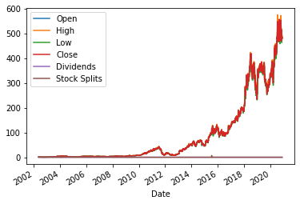

```python
data['prices'].drop('Volume',axis=1).plot(kind='line')
data['prices']
```

```python
data['actions']
```

| Date | Dividends | Stock Splits |
| --- | --- | --- |
| 2004-02-12 | 0.0 | 2.0 |
| 2015-07-15 | 0.0 | 7.0 |

```python
data['major_holders']
```

|  | 0 | 1 |
| --- | --- | --- |
| 0 | 1.55% | % of Shares Held by All Insider |
| 1 | 82.02% | % of Shares Held by Institutions |
| 2 | 83.31% | % of Float Held by Institutions |
| 3 | 2254 | Number of Institutions Holding Shares |

```python
data['institutional_holders']
```

|  | Holder | Shares | Date Reported | % Out | Value |
| --- | --- | --- | --- | --- | --- |
| 0 | Vanguard Group, Inc. (The) | 33583091 | 2020-09-29 | 0.0760 | 16792552992 |
| 1 | Capital Research Global Investors | 30882260 | 2020-09-29 | 0.0699 | 15442056467 |
| 2 | Blackrock Inc. | 29022083 | 2020-09-29 | 0.0657 | 14511912162 |
| 3 | FMR, LLC | 20642740 | 2020-09-29 | 0.0467 | 10321989282 |
| 4 | Price (T.Rowe) Associates Inc | 20121056 | 2020-09-29 | 0.0455 | 10061131631 |
| 5 | State Street Corporation | 16491812 | 2020-09-29 | 0.0373 | 8246400754 |
| 6 | Capital International Investors | 16201903 | 2020-09-29 | 0.0367 | 8101437557 |
| 7 | Capital World Investors | 13649248 | 2020-09-29 | 0.0309 | 6825033477 |
| 8 | Jennison Associates LLC | 8112145 | 2020-09-29 | 0.0184 | 4056315864 |
| 9 | Baillie Gifford and Company | 7411144 | 2020-09-29 | 0.0168 | 3705794334 |

```python
data['events']
```

|  | 0 | 1 |
| --- | --- | --- |
| Earnings Date | 2021-01-19 00:00:00 | 2021-01-25 00:00:00 |
| Earnings Average | 1.38 | 1.38 |
| Earnings Low | 1.34 | 1.34 |
| Earnings High | 1.69 | 1.69 |
| Revenue Average | 6597170000 | 6597170000 |
| Revenue Low | 6538000000 | 6538000000 |
| Revenue High | 6764310000 | 6764310000 |

```python
data['recommendations']
```

| Date | Firm | To Grade | From Grade | Action |
| --- | --- | --- | --- | --- |
| 2012-04-24 07:05:00 | Canaccord Genuity | Sell |  | main |
| 2012-04-24 07:22:00 | Goldman Sachs | Neutral |  | main |
| 2012-04-24 10:14:00 | Dougherty | Neutral |  | main |
| 2012-05-31 06:33:00 | Bank oferica | Underperform |  | main |
| 2012-07-25 05:32:00 | PiperJaffray | Neutral | Overweight | down |
| ... | ... | ... | ... | ... |
| 2020-10-21 11:28:36 | BMO Capital | Outperform |  | main |
| 2020-10-21 11:44:01 | Morgan Stanley | Overweight |  | main |
| 2020-10-21 11:58:29 | Benchmark | Sell |  | main |
| 2020-10-21 16:12:18 | Wedbush | Underperform |  | main |
| 2020-10-21 16:15:07 | Oppenheimer | Outperform |  | main |

459 rows × 4 columns

```python
data['esg']
```

| 2020-10 | Value |
| --- | --- |
| palmOil | False |
| controversialWeapons | False |
| gambling | False |
| socialScore | 7.56 |
| nuclear | False |
| furLeather | False |
| alcoholic | False |
| gmo | False |
| catholic | False |
| socialPercentile | None |
| peerCount | 44 |
| governanceScore | 10.32 |
| environmentPercentile | None |
| animalTesting | False |
| tobacco | False |
| totalEsg | 18.05 |
| highestControversy | 2 |
| esgPerformance | UNDER_PERF |
| coal | False |
| pesticides | False |
| adult | False |
| percentile | 14.5 |
| peerGroup | Media |
| smallArms | False |
| environmentScore | 0.16 |
| governancePercentile | None |
| militaryContract | False |

| date | NETFLIX INC | isPartial |
| --- | --- | --- |
| 2015-11-22 | 55 | False |
| 2015-11-29 | 41 | False |
| 2015-12-06 | 46 | False |
| 2015-12-13 | 39 | False |
| 2015-12-20 | 37 | False |
| ... | ... | ... |
| 2020-10-18 | 59 | False |
| 2020-10-25 | 52 | False |
| 2020-11-01 | 55 | False |
| 2020-11-08 | 54 | False |
| 2020-11-15 | 50 | True |

261 rows × 2 columns

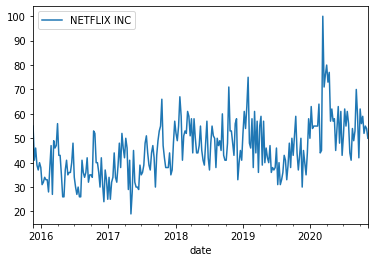

```python
data['interest'].plot(kind='line')
data['interest']
```

# Company Sub Queries

The previous request pulls all data about a given company. This is obviously resource intensive. If you would like to request some subset of the full request, we advise using subfunctions. The following is a list of all available subfunctions.

u.prices(cik_or_ticker) # prices,volume, splits dataframe

u.dividends(cik_or_ticker) # dividend payouts dataframe

u.financial_statement(cik_or_ticker,kind="income") # income statement dataframe

u.financial_statement(cik_or_ticker,kind="balance") # balance sheet dataframe

u.financial_statement(cik_or_ticker,"cash") # cashflow statement dataframe

u.major_sharholders(cik_or_ticker) # major shareholders dataframe

u.major_sharholders(cik_or_ticker) # major shareholders dataframe

u.institutional_holders(cik_or_ticker") # institutional holders dataframe

u.events(cik_or_ticker) # date of events dataframe

u.splits(cik_or_ticker) # stock split events dataframe

u.recommendations(cik_or_ticker) # analyst recommendations dataframe

u.esg(cik_or_ticker) # esg metrics dataframe

u.interest(name) # google trends dataframe

# Example Use Case

I really want to demonstrate the beauty of what we have here since this is often difficult when looking at thousands of numeric datatables. Let's take a very naive peek by plotting various dataframes as timeseries.

Here's how we'd implement that:

```
--------------------------------------------------------------------------------
  			🐋	Welcome to equities.
--------------------------------------------------------------------------------
 Initializing Universe. This may take a second...
> 🏛️	Welcome to polity.
> ✨	Auth success. apis connected.
> 🌌	Universe initialized. size: 4128
 Success. You're good to go!
--------------------------------------------------------------------------------
 Messages:
	Version 4.0 includes all new features!

	🦄 Consider buying me a coffee to fund future development.
	bitcoin wallet address: 3LU5MEaAXRJoCo6vx67g1Jj7qDFRKhMs5t

	Wasssssup IMRDP 2019
--------------------------------------------------------------------------------
> 🛰️	Search query: "XOM" found 1 matches.
> 📦	Fetching company: 34088 ...
> 🛰️	Search query: "MDB" found 1 matches.
> 📦	Fetching company: 1441816 ...
> 🛰️	Search query: "JBLU" found 1 matches.
> 📦	Fetching company: 1158463 ...
```

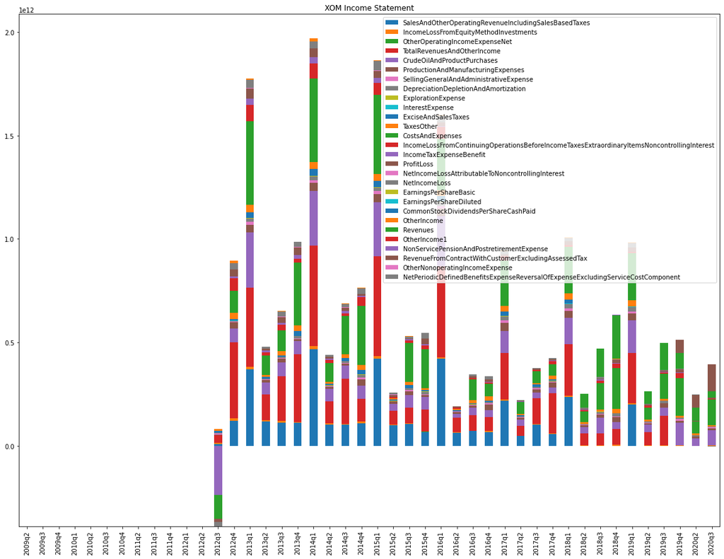

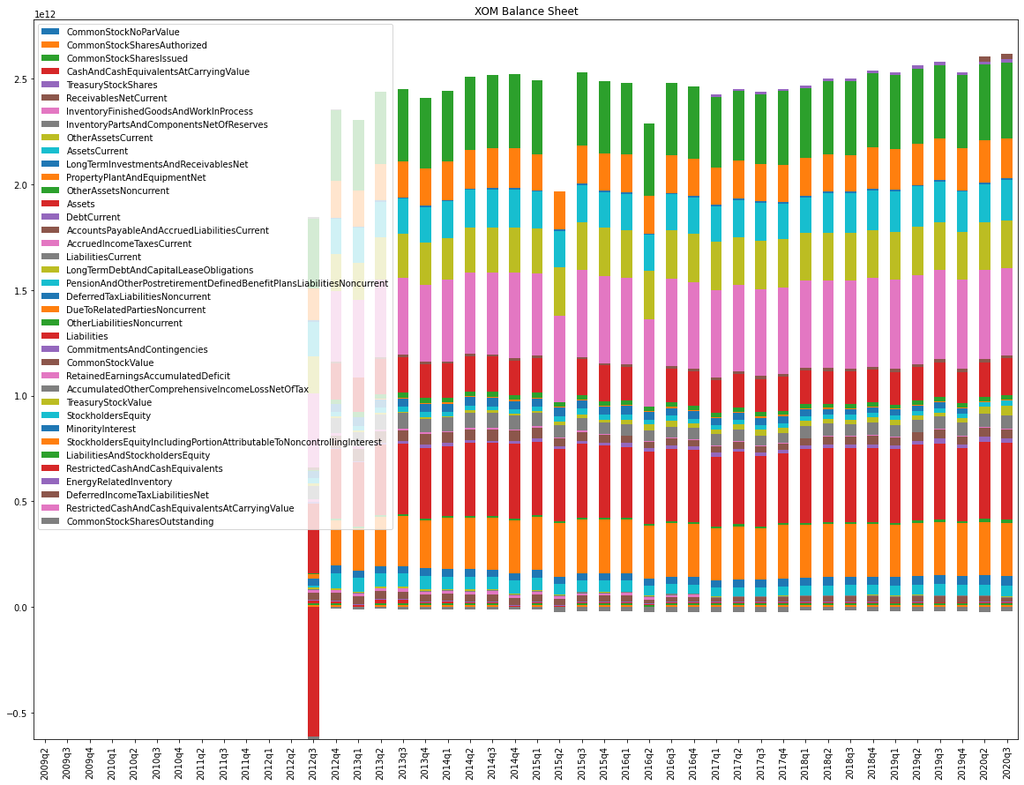

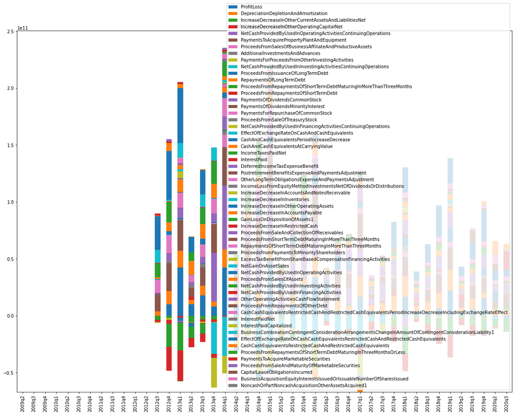

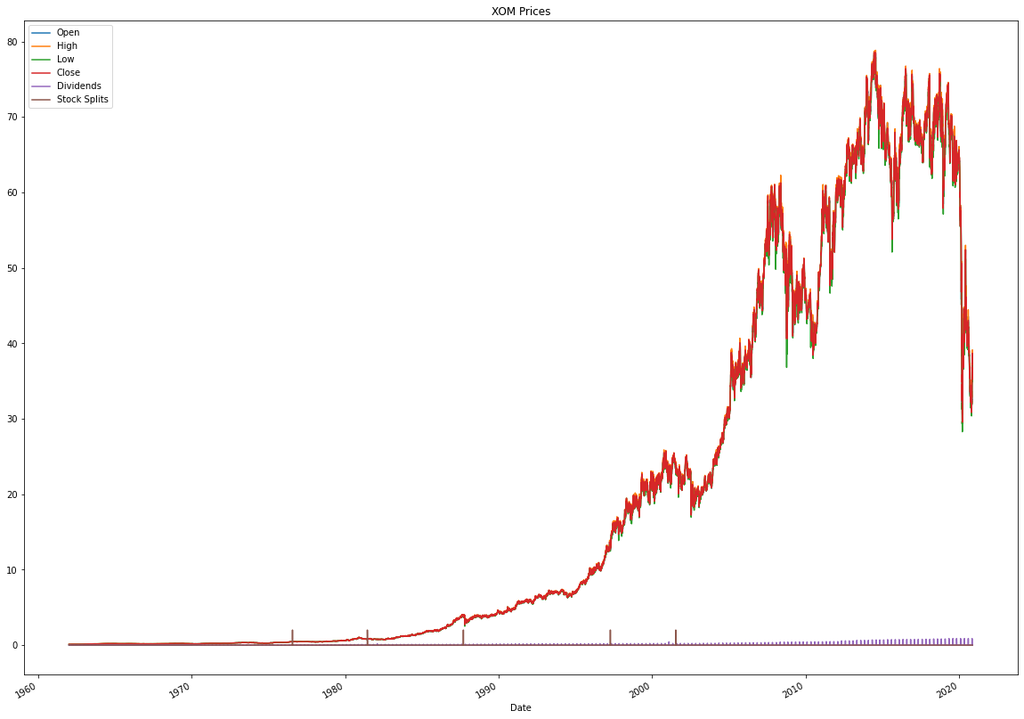

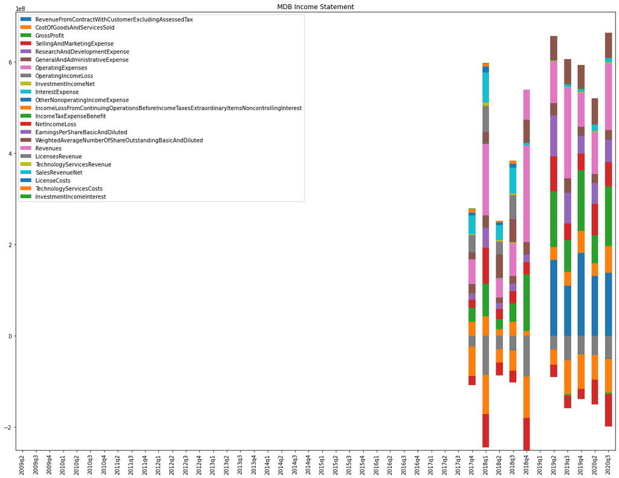

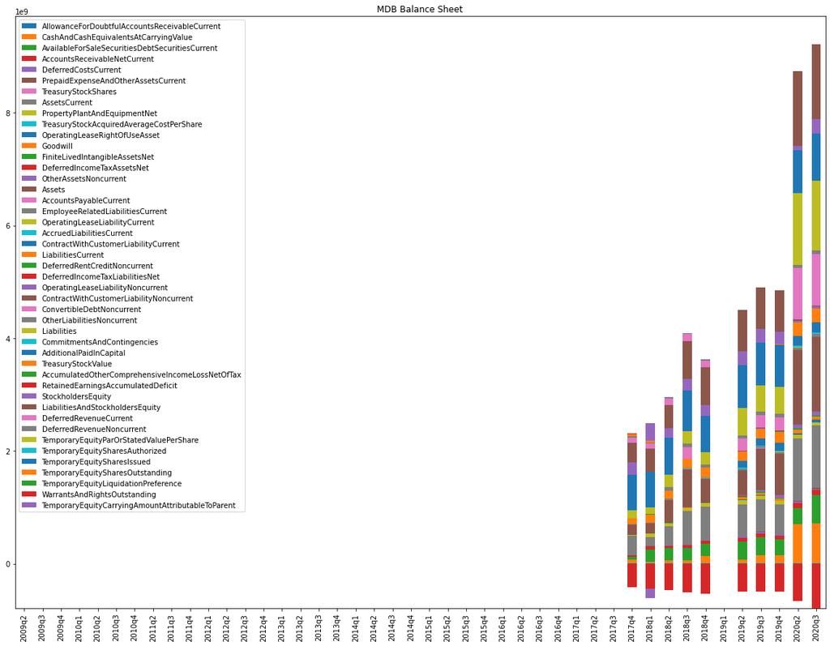

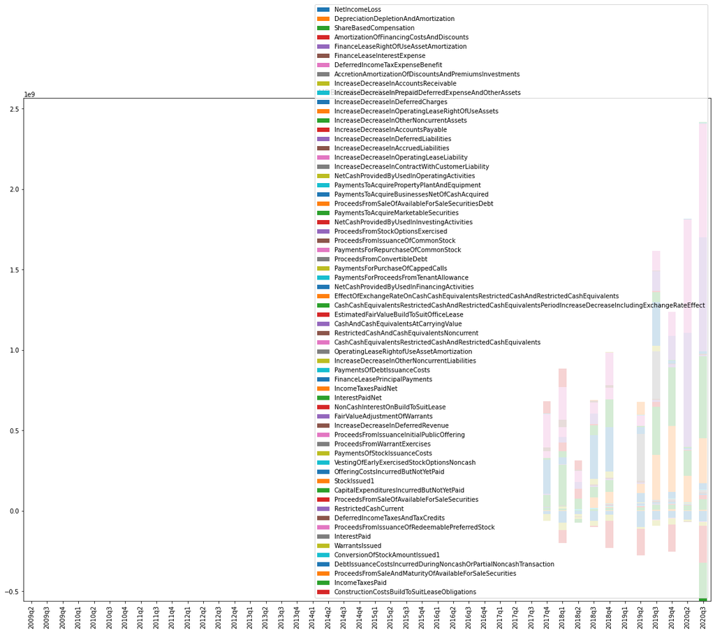

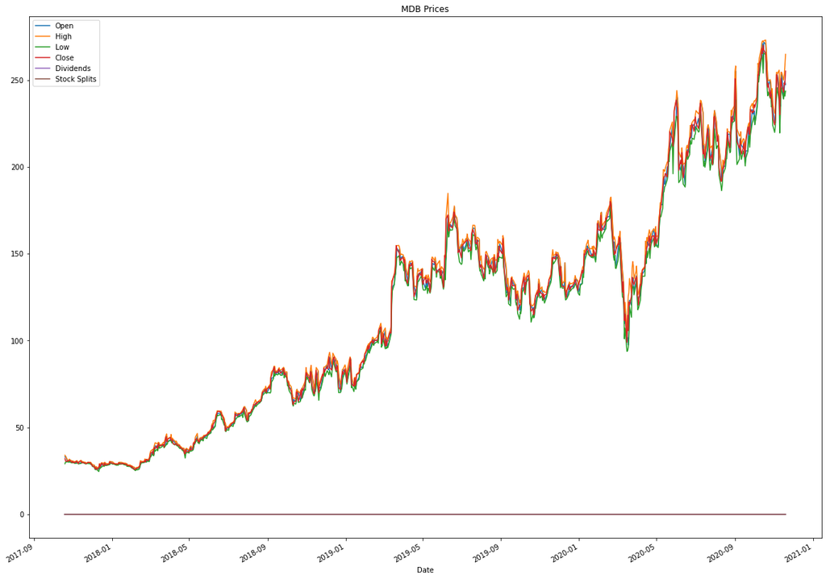

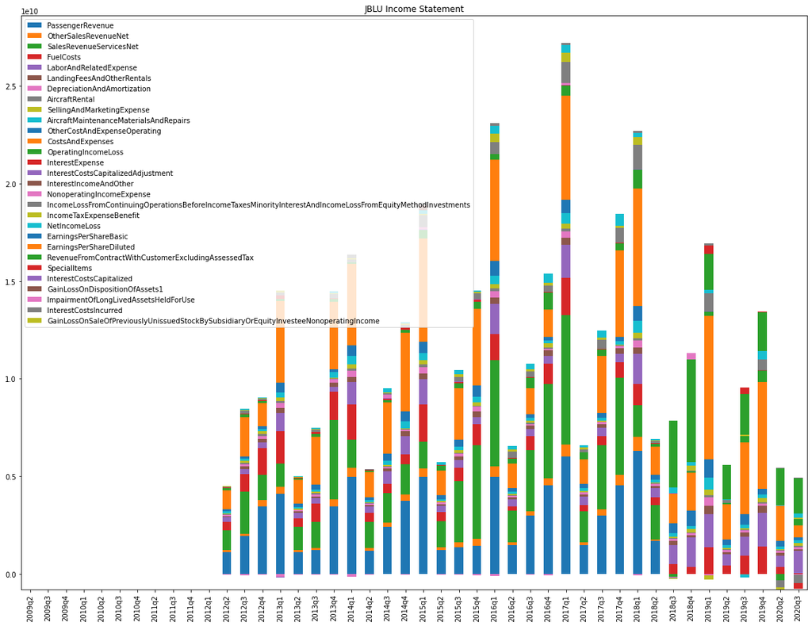

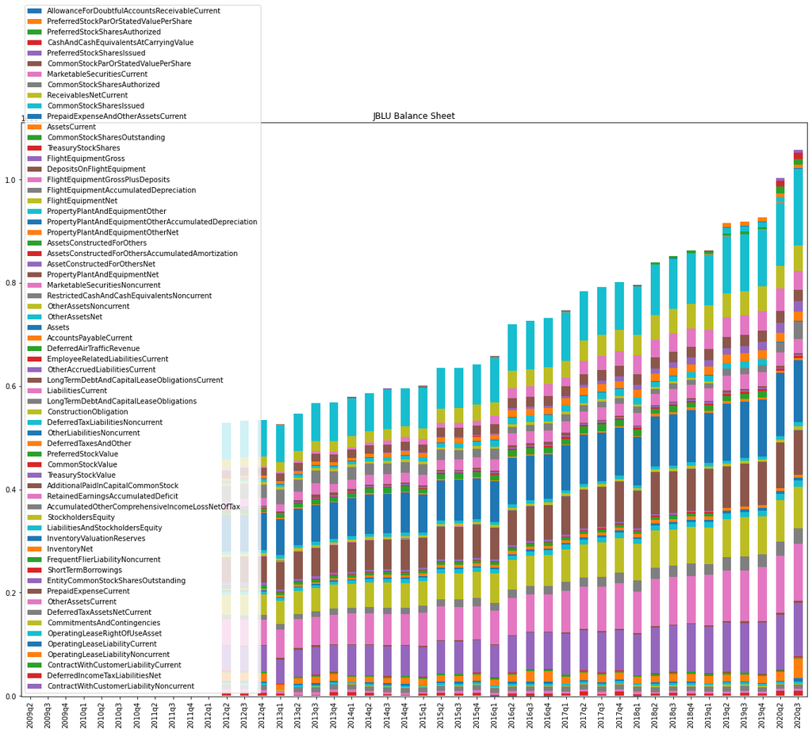

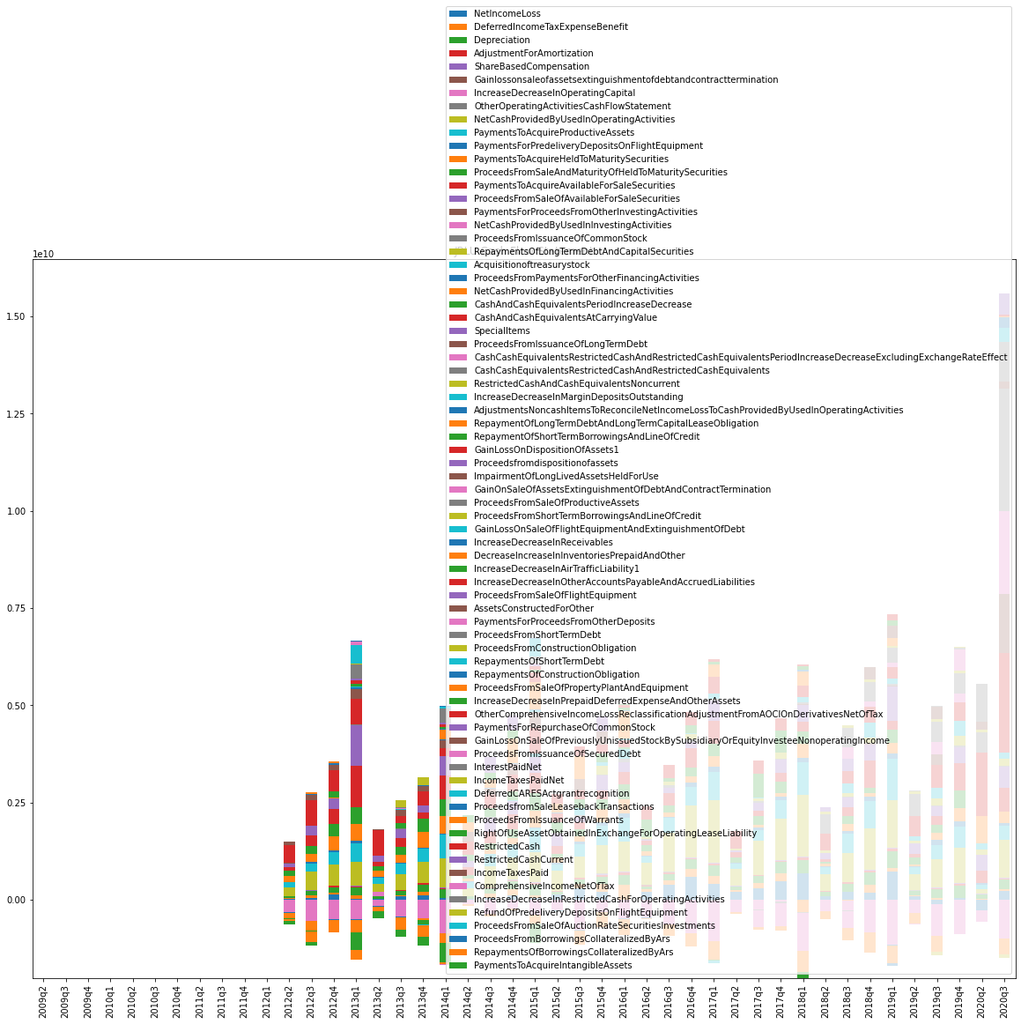

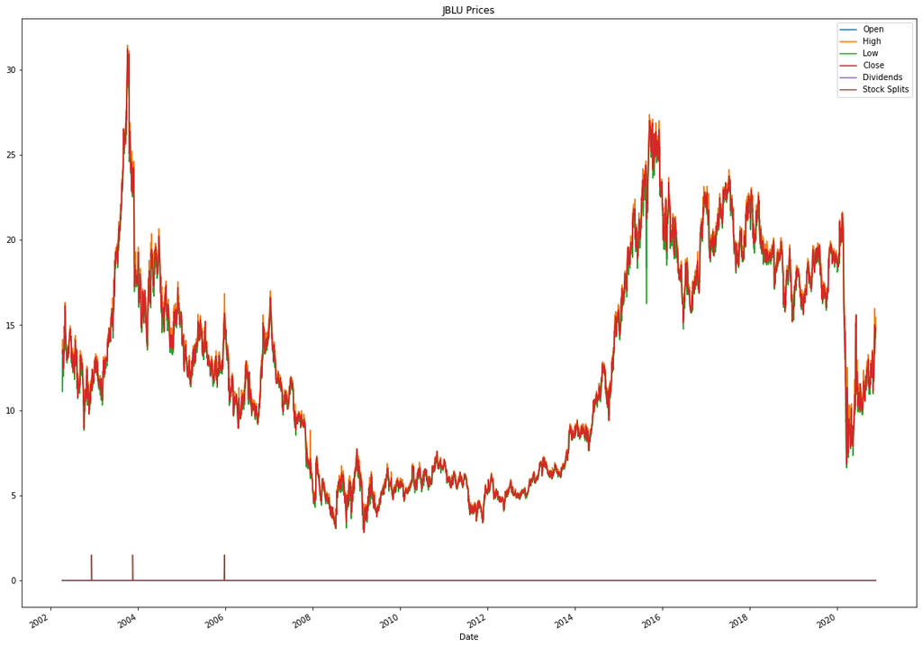

```python
from equities import Universe
import matplotlib.pyplot as plt

u = Universe()
k,f,s = 'bar',(20,15),True

tickers = ['XOM','MDB','JBLU']

for ticker in tickers:

    data = u.company(ticker,search=True)

    income = data['income']
    if not income.empty:
        income.T.plot(
        kind=k,
        figsize=f,
        stacked=s,
        title=ticker + ' Income Statement')

    balance = data['balance']
    if not balance.empty:
        balance.T.plot(
        kind=k,
        figsize=f,
        stacked=s,
        title=ticker+' Balance Sheet')

    cash = data['cash']
    if not cash.empty:
        cash.T.plot(
        kind=k,
        figsize=f,
        stacked=s,
        title = ticker + ' Cash Flow Statement')

    prices = data['prices']
    if not prices.empty:
        prices.drop('Volume',axis=1).plot(
            kind='line',
            figsize=f,
            title = ticker + ' Prices')

    # Notice that the code above is expensive since we are interested in a few fields
    # within the results "c", using sub functions would be much more efficient.

plt.show()
```